# Analisi Infortuni Sportivi

Ivan Buttignon, Pietro Mihelj, Carlotta Sbrugnera

2025-06-20

# ANALISY OF COLLEGE INJURIES DATASET

##Introduction

## Data pre processing

Importing and reading the file saved as a CSV:

```r
injury_df <- read.csv("sports_injury_detection_dataset.csv", header = TRUE, sep = ",")
```

## Esplorazione dei dati

Exploring the summary statistics of the dataset columns:

```r
summary(injury_df)
```

```
##   Athlete_ID         Sport_Type        Session_Date       Heart_Rate_BPM
##  Length:1000        Length:1000        Length:1000        Min.   :100.0
##  Class :character   Class :character   Class :character   1st Qu.:118.0
##  Mode  :character   Mode  :character   Mode  :character   Median :137.0
##                                                           Mean   :138.1
##                                                           3rd Qu.:159.0
##                                                           Max.   :179.0
##  Respiratory_Rate_BPM Skin_Temperature_C Blood_Oxygen_Level_Percent
##  Min.   :16.00        Min.   :36.00      Min.   : 95.00
##  1st Qu.:18.00        1st Qu.:36.35      1st Qu.: 96.44
##  Median :20.00        Median :36.75      Median : 97.66
##  Mean   :19.95        Mean   :36.75      Mean   : 97.61
##  3rd Qu.:22.00        3rd Qu.:37.13      3rd Qu.: 98.82
##  Max.   :24.00        Max.   :37.50      Max.   :100.00
##  Impact_Force_Newtons Cumulative_Fatigue_Index Activity_Type
##  Min.   : 50.03       Min.   :0.2024           Length:1000
##  1st Qu.: 83.93       1st Qu.:0.3441           Class :character
##  Median :119.23       Median :0.4999           Mode  :character
##  Mean   :121.79       Mean   :0.4986
##  3rd Qu.:159.69       3rd Qu.:0.6532
##  Max.   :199.64       Max.   :0.7997
##  Duration_Minutes Injury_Risk_Score Injury_Occurred
##  Min.   :20.00    Min.   :0.3341    Min.   :0.000
##  1st Qu.:37.00    1st Qu.:0.5214    1st Qu.:0.000
##  Median :56.00    Median :0.6008    Median :1.000
##  Mean   :55.24    Mean   :0.6013    Mean   :0.617
##  3rd Qu.:73.00    3rd Qu.:0.6787    3rd Qu.:1.000
##  Max.   :89.00    Max.   :0.8709    Max.   :1.000
```

Notiamo che il dataset è composto da mille osservazioni sia con variabili numeriche che categoriali, decidiamo quindi di convertirne alcune in fattori per una gestione migliore:

```r
injury_df$Sport_Type <- as.factor(injury_df$Sport_Type)
injury_df$Activity_Type <- as.factor(injury_df$Activity_Type)
injury_df$Injury_Occurred <- as.factor(injury_df$Injury_Occurred)
levels(injury_df$Injury_Occurred) <- c("No", "Yes")
```

Visualizziamo tramite un barplot le frequenze assolute delle diverse categorie:

```
## 2 columns ignored with more than 50 categories.
## Athlete_ID: 1000 categories
## Session_Date: 1000 categories
```

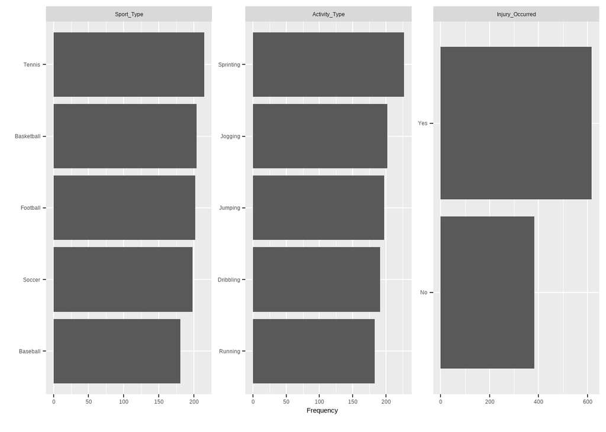

```r
plot_bar(injury_df)
```

La variabile Injury_Occured presenta una pronunciata predominanza della modalità “Yes”. Inoltre osserviamo anche frequenze divise per presenza/assenza di infortunio:

```
## 2 columns ignored with more than 50 categories.
## Athlete_ID: 1000 categories
## Session_Date: 1000 categories
```

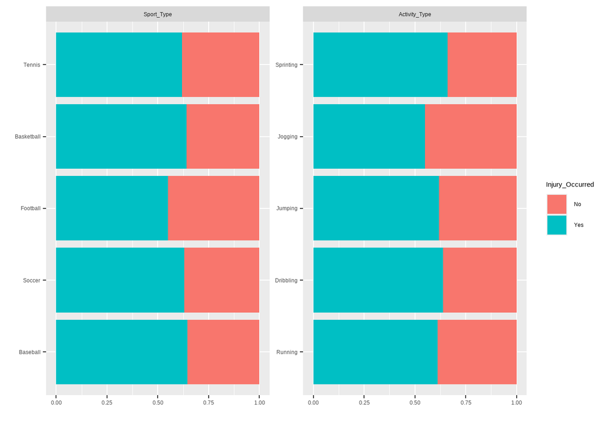

```r
plot_bar(injury_df, by = "Injury_Occurred")
```

## Statistiche descrittive variabili numeriche

Calcoliamo delle statistiche descrittive per tutte le variabili numeriche:

```r
ft1 <- dlookr::describe(injury_df) |>
  flextable() |>
  colformat_double(digits = 2)

ft1
```

| described_variables | n | na | mean | sd | se_mean | IQR | skewness | kurtosis | p00 | p01 | p05 | p10 | p20 | p25 | p30 | p40 | p50 | p60 | p70 | p75 | p80 | p90 | p95 | p99 | p100 |
| --- | --- | --- | --- | --- | --- | --- | --- | --- | --- | --- | --- | --- | --- | --- | --- | --- | --- | --- | --- | --- | --- | --- | --- | --- | --- |
| Heart_Rate_BPM | 1,000 | 0 | 138.12 | 23.09 | 0.73 | 41.00 | 0.02 | -1.21 | 100.00 | 100.00 | 103.00 | 106.00 | 114.00 | 118.00 | 122.00 | 130.00 | 137.00 | 146.40 | 154.30 | 159.00 | 161.00 | 170.00 | 174.00 | 178.00 | 179.00 |
| Respiratory_Rate_BPM | 1,000 | 0 | 19.95 | 2.61 | 0.08 | 4.00 | 0.02 | -1.27 | 16.00 | 16.00 | 16.00 | 16.00 | 17.00 | 18.00 | 18.00 | 19.00 | 20.00 | 21.00 | 22.00 | 22.00 | 23.00 | 24.00 | 24.00 | 24.00 | 24.00 |
| Skin_Temperature_C | 1,000 | 0 | 36.75 | 0.44 | 0.01 | 0.78 | -0.02 | -1.23 | 36.00 | 36.01 | 36.07 | 36.14 | 36.27 | 36.35 | 36.43 | 36.60 | 36.75 | 36.90 | 37.06 | 37.13 | 37.20 | 37.33 | 37.42 | 37.49 | 37.50 |
| Blood_Oxygen_Level_Percent | 1,000 | 0 | 97.61 | 1.42 | 0.04 | 2.37 | -0.12 | -1.12 | 95.00 | 95.06 | 95.25 | 95.58 | 96.11 | 96.44 | 96.75 | 97.19 | 97.66 | 98.13 | 98.62 | 98.82 | 99.04 | 99.52 | 99.74 | 99.94 | 100.00 |
| Impact_Force_Newtons | 1,000 | 0 | 121.79 | 43.57 | 1.38 | 75.76 | 0.09 | -1.23 | 50.03 | 51.45 | 56.79 | 63.65 | 77.18 | 83.93 | 91.57 | 102.01 | 119.23 | 136.95 | 151.38 | 159.69 | 167.94 | 183.73 | 190.86 | 198.47 | 199.64 |
| Cumulative_Fatigue_Index | 1,000 | 0 | 0.50 | 0.17 | 0.01 | 0.31 | 0.02 | -1.22 | 0.20 | 0.21 | 0.23 | 0.26 | 0.31 | 0.34 | 0.37 | 0.44 | 0.50 | 0.56 | 0.62 | 0.65 | 0.68 | 0.75 | 0.77 | 0.79 | 0.80 |
| Duration_Minutes | 1,000 | 0 | 55.24 | 20.37 | 0.64 | 36.00 | -0.04 | -1.21 | 20.00 | 20.00 | 23.00 | 27.00 | 35.00 | 37.00 | 41.00 | 48.00 | 56.00 | 62.00 | 70.00 | 73.00 | 76.00 | 83.00 | 87.00 | 89.00 | 89.00 |
| Injury_Risk_Score | 1,000 | 0 | 0.60 | 0.11 | 0.00 | 0.16 | 0.07 | -0.54 | 0.33 | 0.38 | 0.43 | 0.46 | 0.51 | 0.52 | 0.54 | 0.57 | 0.60 | 0.63 | 0.66 | 0.68 | 0.70 | 0.74 | 0.78 | 0.83 | 0.87 |

Le raggruppiamo anche in base alla variabile infortunio (sì/no)

```r
ft2 <- injury_df |>
  group_by(Injury_Occurred) |>
  univar_numeric() |>
  knitr::kable(digits = 2)
ft2
```

| described_variables | Injury_Occurred | n | na | mean | sd | se_mean | IQR | skewness | median |
| --- | --- | --- | --- | --- | --- | --- | --- | --- | --- |
| Blood_Oxygen_Level_Percent | No | 383 | 0 | 97.58 | 1.42 | 0.07 | 2.36 | -0.13 | 97.58 |
| Blood_Oxygen_Level_Percent | Yes | 617 | 0 | 97.62 | 1.42 | 0.06 | 2.40 | -0.12 | 97.71 |
| Cumulative_Fatigue_Index | No | 383 | 0 | 0.46 | 0.17 | 0.01 | 0.29 | 0.24 | 0.45 |
| Cumulative_Fatigue_Index | Yes | 617 | 0 | 0.52 | 0.17 | 0.01 | 0.31 | -0.13 | 0.53 |
| Duration_Minutes | No | 383 | 0 | 54.45 | 20.35 | 1.04 | 35.00 | 0.04 | 55.00 |
| Duration_Minutes | Yes | 617 | 0 | 55.74 | 20.39 | 0.82 | 35.00 | -0.09 | 57.00 |
| Heart_Rate_BPM | No | 383 | 0 | 137.30 | 22.96 | 1.17 | 39.50 | 0.04 | 137.00 |
| Heart_Rate_BPM | Yes | 617 | 0 | 138.62 | 23.18 | 0.93 | 41.00 | 0.01 | 138.00 |
| Impact_Force_Newtons | No | 383 | 0 | 114.83 | 42.97 | 2.20 | 73.25 | 0.30 | 108.52 |
| Impact_Force_Newtons | Yes | 617 | 0 | 126.11 | 43.41 | 1.75 | 75.27 | -0.03 | 126.83 |
| Injury_Risk_Score | No | 383 | 0 | 0.58 | 0.10 | 0.01 | 0.15 | 0.23 | 0.57 |
| Injury_Risk_Score | Yes | 617 | 0 | 0.62 | 0.11 | 0.00 | 0.15 | -0.03 | 0.61 |
| Respiratory_Rate_BPM | No | 383 | 0 | 19.98 | 2.63 | 0.13 | 4.00 | 0.00 | 20.00 |
| Respiratory_Rate_BPM | Yes | 617 | 0 | 19.93 | 2.60 | 0.10 | 4.00 | 0.03 | 20.00 |
| Skin_Temperature_C | No | 383 | 0 | 36.72 | 0.45 | 0.02 | 0.78 | 0.10 | 36.71 |
| Skin_Temperature_C | Yes | 617 | 0 | 36.76 | 0.43 | 0.02 | 0.75 | -0.10 | 36.79 |

Notiamo, dai valori molto vicini a 0 della skewness, che le distribuzioni sono tutte abbastanza simmetriche sia generalmente che divise per la variabile target (injury_occurred)

## Analisi della normalità

Come prima cosa facciamo un test di normalità sulle distribuzioni delle variabili continue. Tutte le distribuzioni sembrano non seguire la normalità, pero il dataset ha molti dati quindi andiamo a controllare anche la forma delle distribuzioni ed i qq-plot per assicurarci della non normalità.

```r
normality(injury_df) |>
  mutate_if(is.numeric, ~ round(., 3)) |>
  flextable()
```

| vars | statistic | p_value | sample |
| --- | --- | --- | --- |
| Heart_Rate_BPM | 0.953 | 0.000 | 1,000 |
| Respiratory_Rate_BPM | 0.927 | 0.000 | 1,000 |
| Skin_Temperature_C | 0.951 | 0.000 | 1,000 |
| Blood_Oxygen_Level_Percent | 0.959 | 0.000 | 1,000 |
| Impact_Force_Newtons | 0.950 | 0.000 | 1,000 |
| Cumulative_Fatigue_Index | 0.952 | 0.000 | 1,000 |
| Duration_Minutes | 0.953 | 0.000 | 1,000 |
| Injury_Risk_Score | 0.994 | 0.001 | 1,000 |

Verifica visiva della distribuzione con density plot:

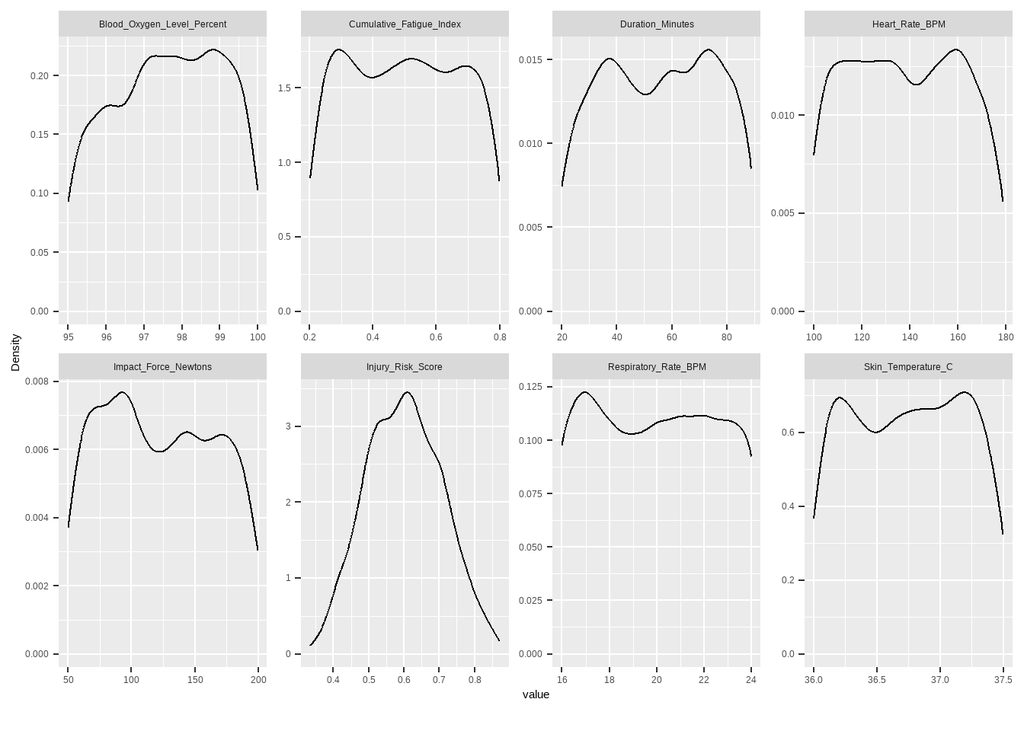

```r
plot_density(injury_df)
```

Ipotizziamo una distribuzione normale solo per Injury_Risk_Score.

Proseguiamo tracciando i QQ-plot per ogni variabile numerica, divisa per Injury_Occurred, in modo da poter confrontare la distribuzione delle variabili con quelle di una normale

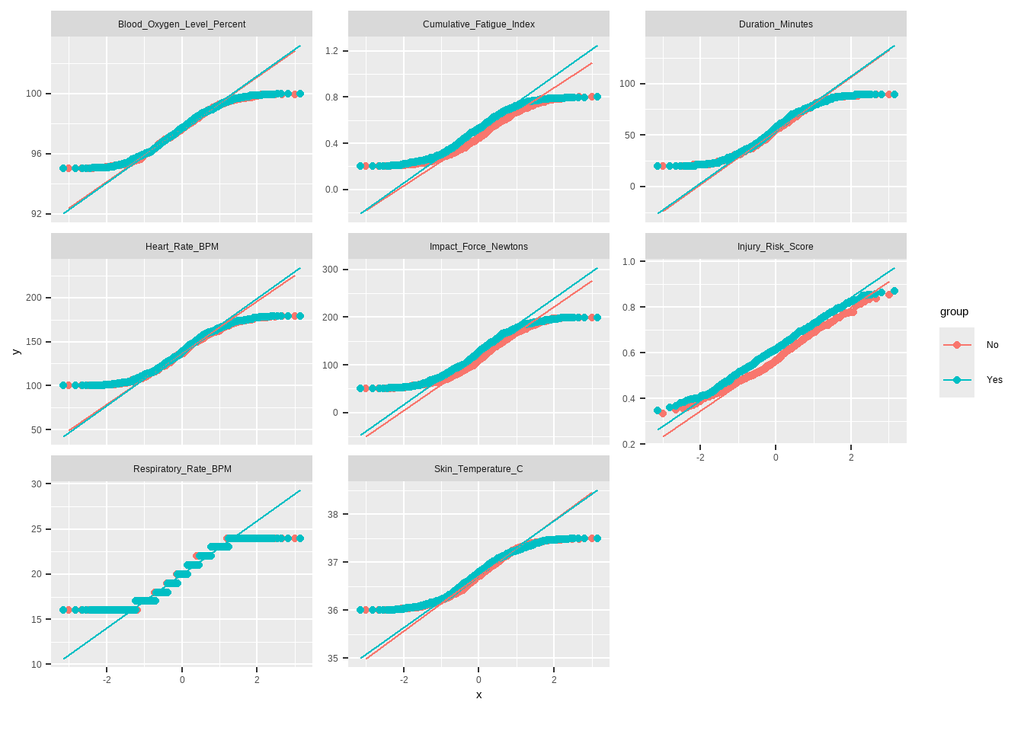

```r
plot_qq(injury_df, by = "Injury_Occurred")
```

Notiamo che nemmeno suddividendo le distribuzioni per le classi della variabil etarget si trova un comportamento normale. Si compie un tentativo di normalizzazione tramite funzione logaritmica.

## Tentativo di normalizzazione: LOG TRASFORMAZIONE

Definiamo variabili da log-trasformare (solo se >= 0)

```r
vars_to_plot <- c(
  "Blood_Oxygen_Level_Percent", "Cumulative_Fatigue_Index",
  "Duration_Minutes", "Heart_Rate_BPM", "Impact_Force_Newtons",
  "Injury_Risk_Score", "Respiratory_Rate_BPM", "Skin_Temperature_C"
)

injury_df_log <- injury_df |>
  filter(across(all_of(vars_to_plot), ~ . > 0)) |>
  mutate(across(all_of(vars_to_plot), log, .names = "log_{.col}"))
```

Estraiamo variabili log trasformate per QQ-plot

```r
log_vars <- paste0("log_", vars_to_plot)
injury_df_log_subset <- injury_df_log |>
  select(all_of(log_vars), Injury_Occurred)
```

Creiamo QQ-plot per le log-trasformate

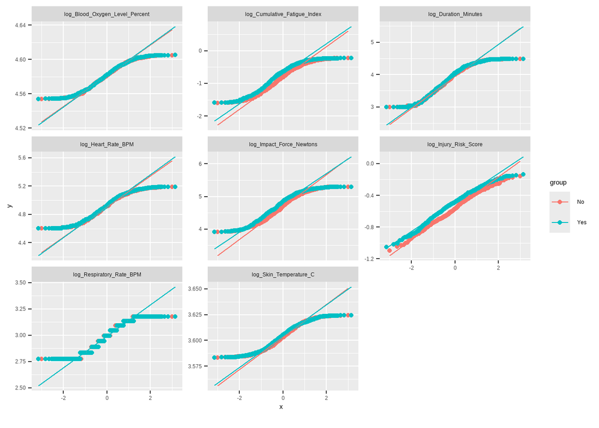

```r
plot_qq(injury_df_log_subset, by = "Injury_Occurred")
```

Effettuiamo il test della normalità:

```r
normality(injury_df_log |> select(starts_with("log_"))) |>
  mutate_if(is.numeric, ~ round(., 3)) |>
  flextable()
```

| vars | statistic | p_value | sample |
| --- | --- | --- | --- |
| log_Blood_Oxygen_Level_Percent | 0.959 | 0 | 1,000 |
| log_Cumulative_Fatigue_Index | 0.939 | 0 | 1,000 |
| log_Duration_Minutes | 0.932 | 0 | 1,000 |
| log_Heart_Rate_BPM | 0.951 | 0 | 1,000 |
| log_Impact_Force_Newtons | 0.945 | 0 | 1,000 |
| log_Injury_Risk_Score | 0.988 | 0 | 1,000 |
| log_Respiratory_Rate_BPM | 0.926 | 0 | 1,000 |
| log_Skin_Temperature_C | 0.951 | 0 | 1,000 |

Dopo la trasformazione logaritmica, è stato eseguito nuovamente il test di Shapiro-Wilk per valutare la normalità delle variabili e restano non normali. Pertanto si preferiscono approcci non parametrici.

## Analisi bivariate

### Variabili Categoriali

#### Sport_Type ~ Injury_Occured

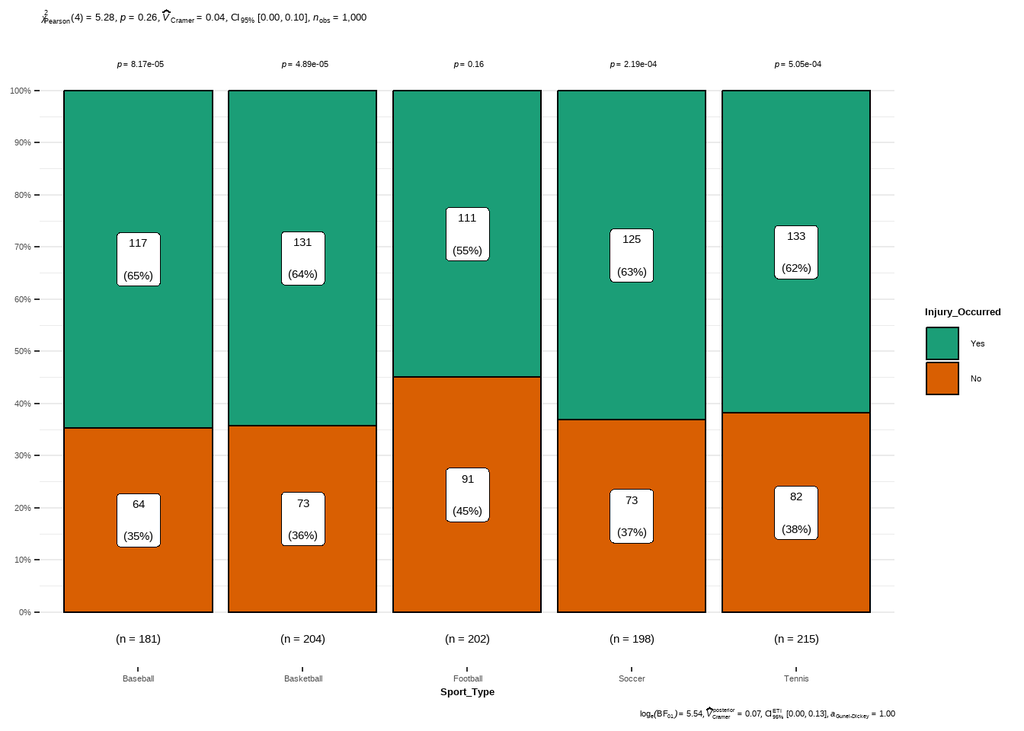

```r
ggbarstats(data  = injury_df, x = Injury_Occurred, y = Sport_Type, label = "both")
```

Il valore del p-value mostrato nel grafico su un test del χ2 è non significativo e quindi le 2 variabili non sono correlate

### Activity_Type ~ Injury_Occured

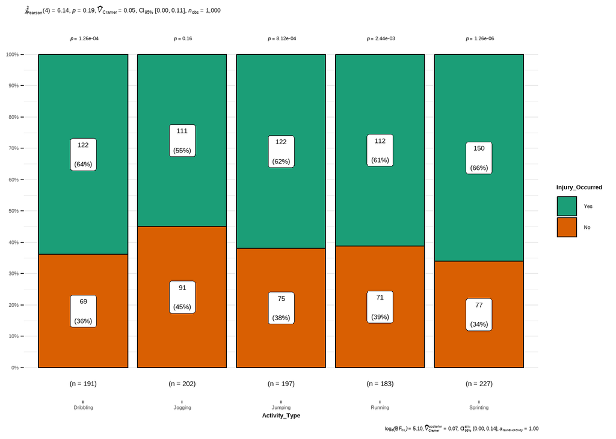

```r
ggbarstats(data  = injury_df, x = Injury_Occurred, y = Activity_Type, label = "both")
```

Anche in questo caso si possono trarre le stesse conclusioni della precedente analisi, in quanto essendo il p-value troppo elevato non ci aspettiamo una relazione tra le attivite praticate e le lesioni subite.

### Variabili Continue

andiamo a utilizzare una serie di boxplot per vedere quali variabili continue sono interessanti

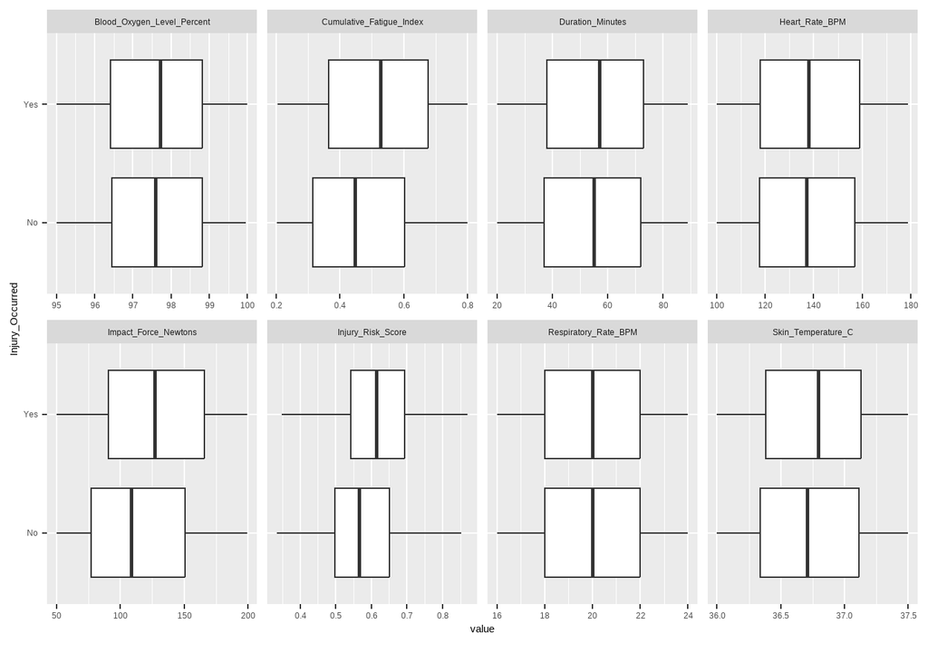

```r
plot_boxplot(injury_df, by = "Injury_Occurred")
```

Notiamo che le variabili che sembrano avere una differenza tra le medie sono solamente: Cumulative_Fatigue_Index, Impact_Force_Newtons,Injury_Risk_Score. Andiamo quindi a vedere come queste si comportano e se sono effettivamente interessanti

#### Impact_force_newton ~ Injury_Occured

Andiamo ad applicare il test di Mann-Whitney non parametrico per confrontare l’impatto della forza tra soggetti con e senza infortunio.

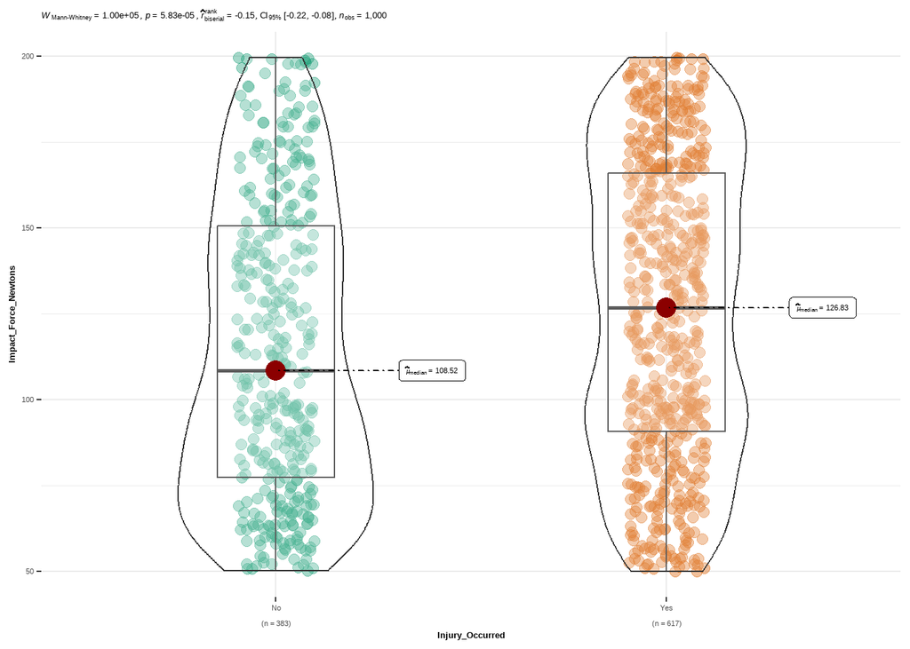

```r
ggbetweenstats(data = injury_df, x = Injury_Occurred, y = Impact_Force_Newtons, type = "np")
```

Dal test appena effettuato ricaviamo che le forze d’impatto nei soggetti con infortunio sono significativamente diverse da quelle nei soggetti senza infortunio, suggerendo che un impatto maggiore potrebbe essere associato ad un rischio aumentato di infortunio. Quindi la variabile sarà utile da usare in un modello predittivo

#### Cumulative_Fatigue_Index ~ Injury_Occured

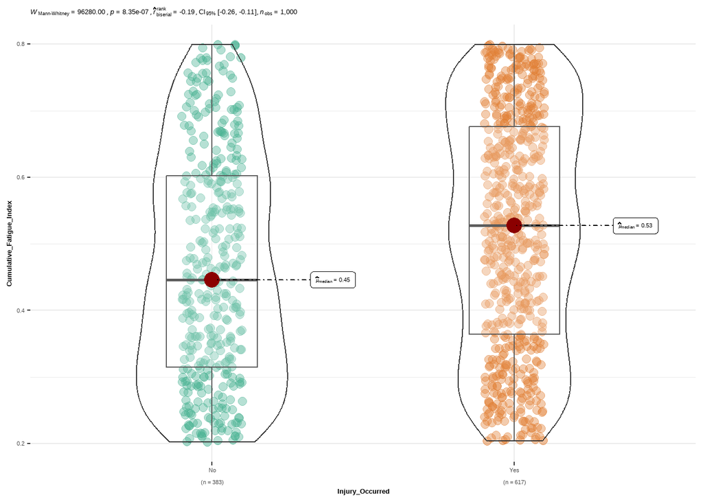

```r
ggbetweenstats(data = injury_df, x = Injury_Occurred, y = Cumulative_Fatigue_Index, type = "np")
```

Anche in questo caso notiamo come nei soggetti più affaticati siano più comuni lesioni. Le conclusioni sono quindi analoghe al caso precedente

#### Injury_Risk_Score ~ Injury_Occured

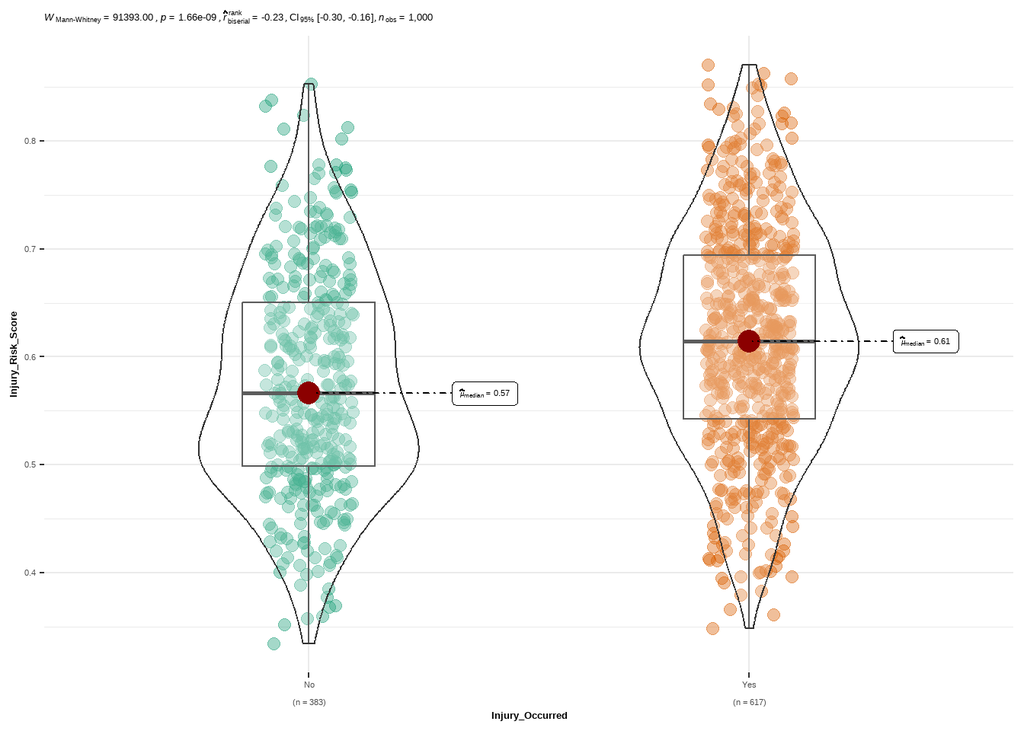

```r
ggbetweenstats(data = injury_df, x = Injury_Occurred, y = Injury_Risk_Score, type = "np")
```

La differenza tra le medie è chiaramente rilevante in questa occasione. Non ci piace molto però il fatto che le distribuzioni siano abbastanza simili nelle 2 classi. Ci aspetteremmo invece che la distribuzione tra i non infortunati sia molto concentrata in basso con una coda verso i valori più alti, e viceversa per chi ha subito infortuni. questo ci porta a voler creare un nuovo metodo per dare una probabilità di infortunio.

## Confaunders

Diventa adesso necessario verificare la presenza di confaunder per le variabili che abbiamo individiato come interessanti.

### Matrice di correlazione (Spearman) per variabili numeriche

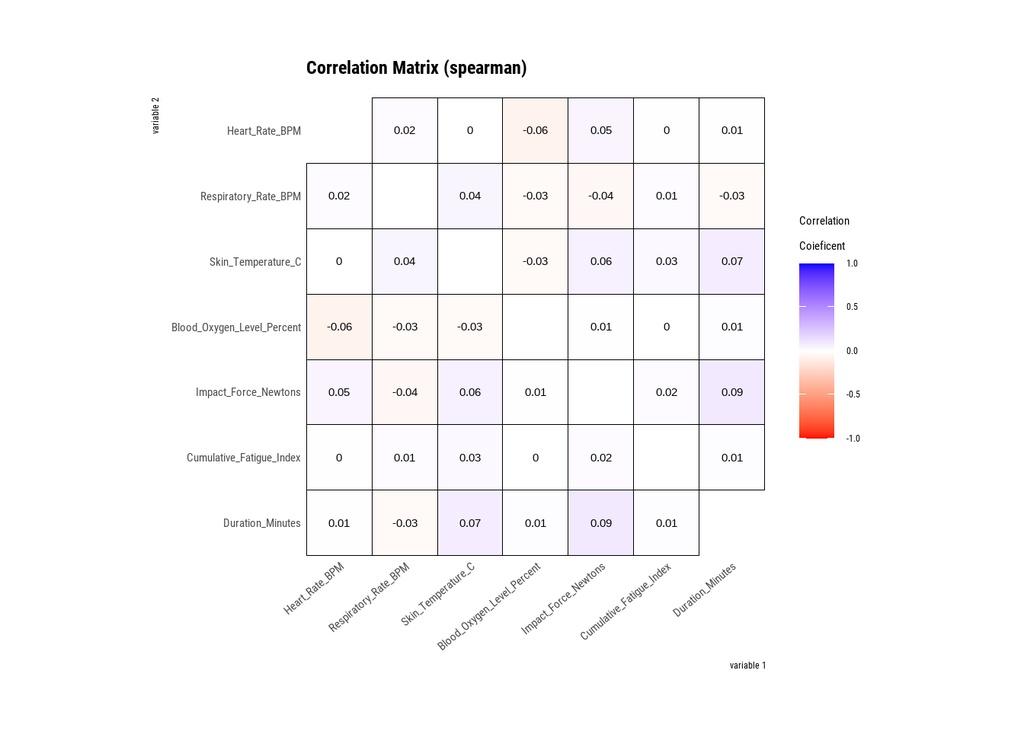

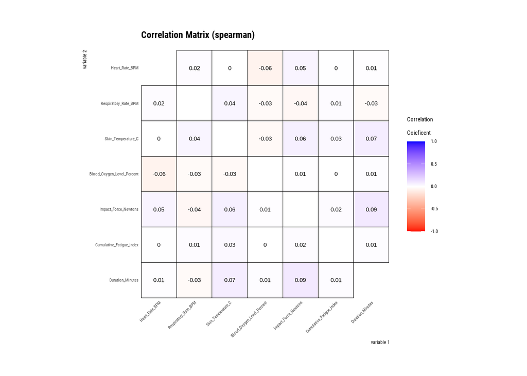

```r
cc <- correlate(injury_df[,-12], method="spearman")
plot(cc)+
  ggplot2::theme(axis.text.x = ggplot2::element_text(angle = 45, hjust = 1, size = 8),
                 axis.text.y = ggplot2::element_text(size = 8))
```

Innanzitutto bisogna far notare che abbiamo tolto la variabile injury_risk_score poichè è qualcosa di artificialmente calcolato, quindi non tecnicamente una caratteristica del dato, ed è ora diventato un target da ricalcolare. oltre a ciò notiamo che tutte le correlazioni sono praticamente nulle e non rilevanti. Concludiamo quindi che non ci sono confaunders tra le variabili numeriche

### Test di Kurskal-Wallis per variabili categoriali

```r
I_S <- kruskal.test(Impact_Force_Newtons ~ Sport_Type, data = injury_df)
I_A <- kruskal.test(Impact_Force_Newtons ~ Activity_Type, data = injury_df)
C_S <- kruskal.test(Cumulative_Fatigue_Index ~ Sport_Type, data = injury_df)
C_A <- kruskal.test(Cumulative_Fatigue_Index ~ Activity_Type, data = injury_df)

tavola <- data.frame(
  K_W_Value = c(as.numeric(I_S$statistic), as.numeric(I_A$statistic), as.numeric(C_S$statistic), as.numeric(C_A$statistic)),
  p_Value = c(as.numeric(I_S$p.value), as.numeric(I_A$p.value), as.numeric(C_S$p.value), as.numeric(C_A$p.value))
)
rownames(tavola) <- c("Impact_Force_Newtons ~ Sport_Type", "Impact_Force_Newtons ~ Activity_Type", "Cumulative_Fatigue_Index ~ Sport_Type", "Cumulative_Fatigue_Index ~ Activity_Type")
tavola
```

|  | K_W_Value | p_Value |
| --- | --- | --- |
| Impact_Force_Newtons ~ Sport_Type | 1.277495 | 0.8651822 |
| Impact_Force_Newtons ~ Activity_Type | 2.255690 | 0.6888475 |
| Cumulative_Fatigue_Index ~ Sport_Type | 4.383523 | 0.3565830 |
| Cumulative_Fatigue_Index ~ Activity_Type | 5.466710 | 0.2426713 |

Andando a vedere i p-Value notiamo facilmente che nessuna delle coppie ha una relazione significativa. Quindi nemmeno tra le variabili categoriali ci sono dei confaunders

## Modello predittivo

### Regressione logistica

Costruiamo un modello logistico con solo due variabili (Impact_Force_Newtons e Cumulative_Fatigue_Index), poichè abbiamo gia osservato essere le uniche con una relazione significativa verso la variabile target.

```r
pred1 = glm(data = injury_df, Injury_Occurred ~ Impact_Force_Newtons + Cumulative_Fatigue_Index, family = binomial)
summary(pred1)
```

```
##
## Call:
## glm(formula = Injury_Occurred ~ Impact_Force_Newtons + Cumulative_Fatigue_Index,
##     family = binomial, data = injury_df)
##
## Coefficients:
##                           Estimate Std. Error z value Pr(>|z|)
## (Intercept)              -1.179079   0.274210  -4.300 1.71e-05 ***
## Impact_Force_Newtons      0.006081   0.001543   3.941 8.11e-05 ***
## Cumulative_Fatigue_Index  1.878451   0.385348   4.875 1.09e-06 ***
## ---
## Signif. codes:  0 '***' 0.001 '**' 0.01 '*' 0.05 '.' 0.1 ' ' 1
##
## (Dispersion parameter for binomial family taken to be 1)
##
##     Null deviance: 1331.0  on 999  degrees of freedom
## Residual deviance: 1290.7  on 997  degrees of freedom
## AIC: 1296.7
##
## Number of Fisher Scoring iterations: 4
```

I p-value confermano la significatività delle variabili. Calcoliamo le probabilità di infortunio per ogni osservazione e classifichiamo in base a una soglia di 0.5.

```r
prob <- predict(pred1, type = "response")
pred_class <- ifelse(prob > 0.5, 1, 0)
```

Creiamo la matrice di confusione per confrontare le predizioni con i dati reali e calcoliamo le metriche: accuracy, sensitivity, specificity.

```r
conf_matrix <- table(Predicted = pred_class, Actual = injury_df$Injury_Occurred)
print(conf_matrix)
```

```
##          Actual
## Predicted  No Yes
##         0  71  57
##         1 312 560
```

```r
TP <- conf_matrix[2, 2]
TN <- conf_matrix[1, 1]
FP <- conf_matrix[2, 1]
FN <- conf_matrix[1, 2]

accuracy <- (TP + TN) / sum(conf_matrix)
sensitivity <- TP / (TP + FN)
specificity <- TN / (TN + FP)

cat("Accuracy: ", round(accuracy, 3), "\n")
```

```
## Accuracy:  0.631
```

```r
cat("Sensitivity (Recall): ", round(sensitivity, 3), "\n")
```

```
## Sensitivity (Recall):  0.908
```

```r
cat("Specificity: ", round(specificity, 3), "\n")
```

```
## Specificity:  0.185
```

Costruiamo la curva ROC e calcoliamo l’AUC per valutare la capacità discriminante del modello su tutte le soglie.

```r
roc_obj <- roc(injury_df$Injury_Occurred, prob)
```

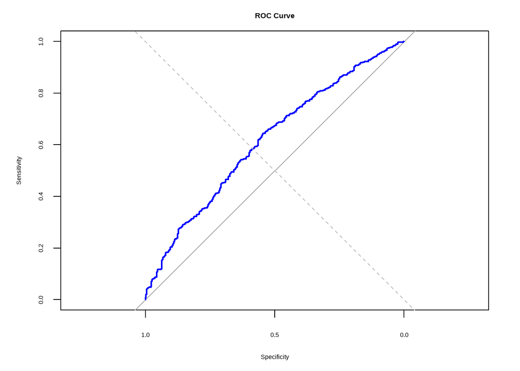

```r
auc_val <- auc(roc_obj)
plot(roc_obj, col = "blue", main = "ROC Curve")
abline(a = 0, b = 1, lty = 2, col = "gray")
```

```r
cat("AUC: ", round(auc_val, 3), "\n")
```

```
## AUC:  0.616
```

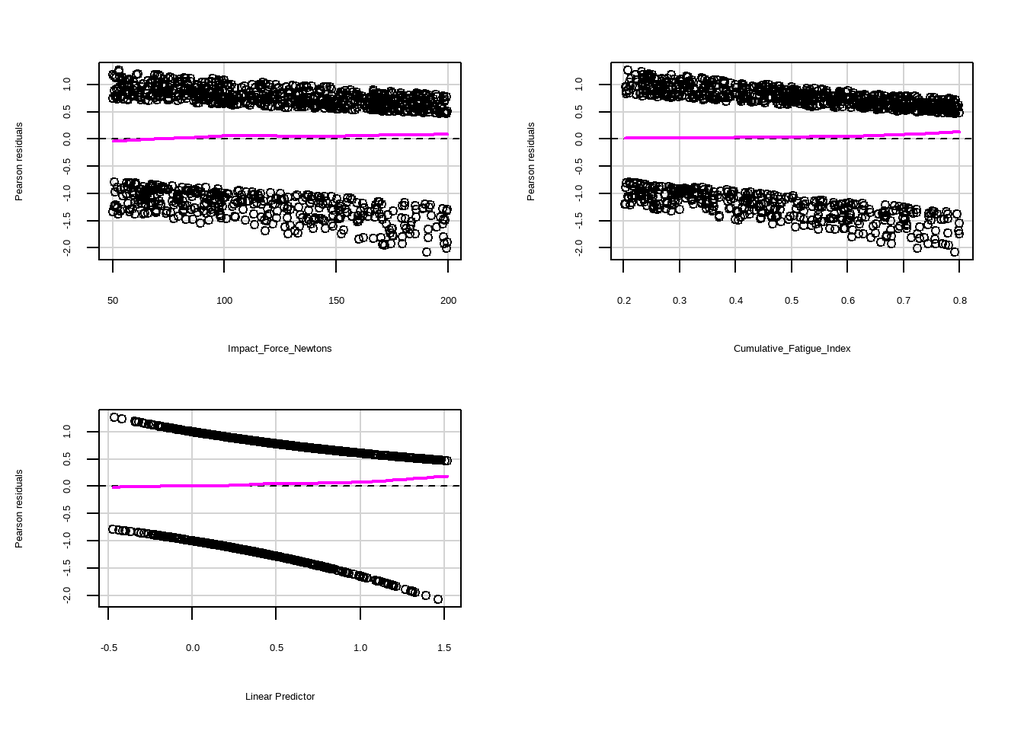

```
##                          Test stat Pr(>|Test stat|)
## Impact_Force_Newtons        0.1505           0.6981
## Cumulative_Fatigue_Index    0.1881           0.6645
```

```r
residualPlots(pred1)
```

I risultati di ROC e acuracy non sono soddisfacenti. D’altro canto i residui sono invece buoni, i test confermano che non ci sono delle relazioni non lineari. L’unica cosa strana che notiamo è un po di scostamento agli estremi ed una leggera forma curva. Andiamo quindi a considerare la relazione tra le 2 variabili per vedere se un modello complesso porta prestazioni migliori

```r
pred2 = glm(data = injury_df, Injury_Occurred ~ Impact_Force_Newtons*Cumulative_Fatigue_Index, family = binomial)
summary(pred2)
```

```
##
## Call:
## glm(formula = Injury_Occurred ~ Impact_Force_Newtons * Cumulative_Fatigue_Index,
##     family = binomial, data = injury_df)
##
## Coefficients:
##                                                Estimate Std. Error z value
## (Intercept)                                   -1.031008   0.580966  -1.775
## Impact_Force_Newtons                           0.004866   0.004479   1.086
## Cumulative_Fatigue_Index                       1.576337   1.113903   1.415
## Impact_Force_Newtons:Cumulative_Fatigue_Index  0.002490   0.008621   0.289
##                                               Pr(>|z|)
## (Intercept)                                      0.076 .
## Impact_Force_Newtons                             0.277
## Cumulative_Fatigue_Index                         0.157
## Impact_Force_Newtons:Cumulative_Fatigue_Index    0.773
## ---
## Signif. codes:  0 '***' 0.001 '**' 0.01 '*' 0.05 '.' 0.1 ' ' 1
##
## (Dispersion parameter for binomial family taken to be 1)
##
##     Null deviance: 1331.0  on 999  degrees of freedom
## Residual deviance: 1290.6  on 996  degrees of freedom
## AIC: 1298.6
##
## Number of Fisher Scoring iterations: 4
```

I p-value che osserviamo non ci fanno ben sperare. Ed infatti le prestazioni non sono migliorate

```r
prob <- predict(pred2, type = "response")
pred_class <- ifelse(prob > 0.5, 1, 0)
conf_matrix <- table(Predicted = pred_class, Actual = injury_df$Injury_Occurred)
print(conf_matrix)
```

```
##          Actual
## Predicted  No Yes
##         0  66  54
##         1 317 563
```

```r
TP <- conf_matrix[2, 2]
TN <- conf_matrix[1, 1]
FP <- conf_matrix[2, 1]
FN <- conf_matrix[1, 2]

accuracy <- (TP + TN) / sum(conf_matrix)
sensitivity <- TP / (TP + FN)
specificity <- TN / (TN + FP)

cat("Accuracy: ", round(accuracy, 3), "\n")
```

```
## Accuracy:  0.629
```

```r
cat("Sensitivity (Recall): ", round(sensitivity, 3), "\n")
```

```
## Sensitivity (Recall):  0.912
```

```r
cat("Specificity: ", round(specificity, 3), "\n")
```

```
## Specificity:  0.172
```

```r
roc_obj <- roc(injury_df$Injury_Occurred, prob)
```

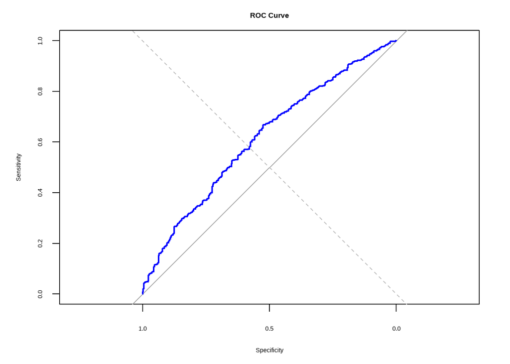

```r
auc_val <- auc(roc_obj)
plot(roc_obj, col = "blue", main = "ROC Curve")
abline(a = 0, b = 1, lty = 2, col = "gray")
```

```r
cat("AUC: ", round(auc_val, 3), "\n")
```

```
## AUC:  0.616
```

Proviamo quindi ad utilizzare un modello completamente diverso. Per poter mantenere un minimo di spiegabilità usiamo degli alberi

### Decision tree

```r
tree_model <- rpart(Injury_Occurred ~ Impact_Force_Newtons + Cumulative_Fatigue_Index,
                    data = injury_df, method = "class", control = rpart.control(minsplit = 20, cp = 0.001))
```

Procediamo a visualizzare l’albero

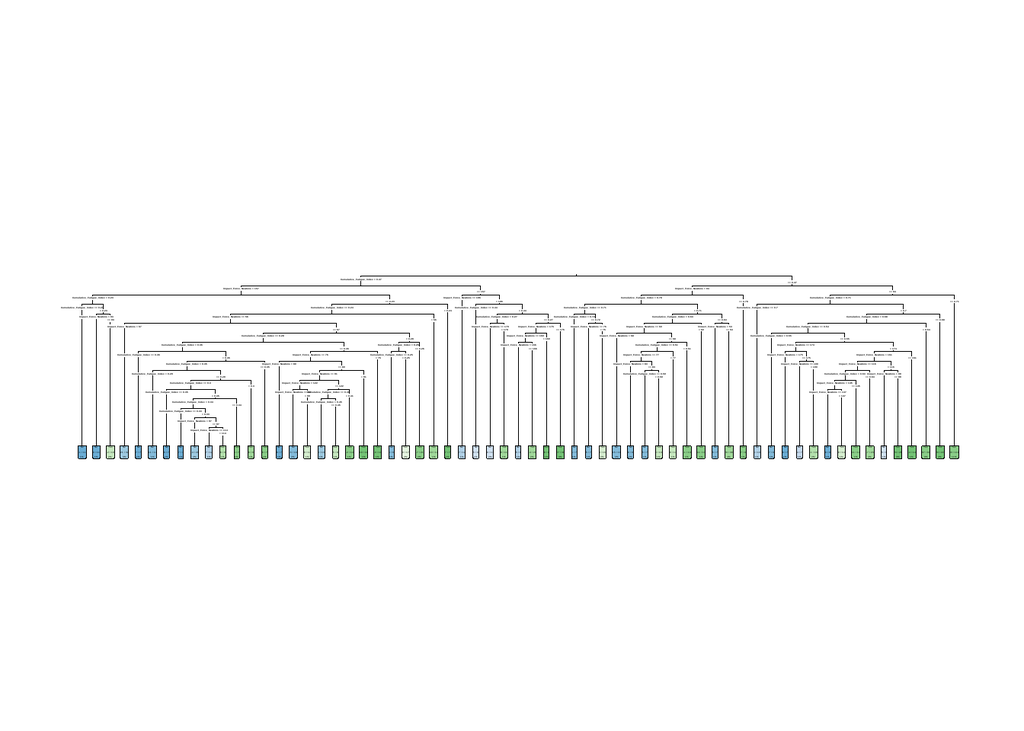

```r
rpart.plot(tree_model, type = 3, extra = 102, fallen.leaves = TRUE)
```

Effettuiamo la predizione delle classi e calcoliamo la matrice di confusione per valutare il modello.

```r
pred_class <- predict(tree_model, type = "class")
pred_prob <- predict(tree_model)[, 2]

conf_matrix <- table(Predicted = pred_class, Actual = injury_df$Injury_Occurred)
print(conf_matrix)
```

```
##          Actual
## Predicted  No Yes
##       No  232  88
##       Yes 151 529
```

```r
TP <- conf_matrix["Yes", "Yes"]
TN <- conf_matrix["No", "No"]
FP <- conf_matrix["Yes", "No"]
FN <- conf_matrix["No", "Yes"]

accuracy <- (TP + TN) / sum(conf_matrix)
sensitivity <- TP / (TP + FN)
specificity <- TN / (TN + FP)

cat("Accuracy: ", round(accuracy, 3), "\n")
```

```
## Accuracy:  0.761
```

```r
cat("Sensitivity: ", round(sensitivity, 3), "\n")
```

```
## Sensitivity:  0.857
```

```r
cat("Specificity: ", round(specificity, 3), "\n")
```

```
## Specificity:  0.606
```

Valutiamo la performance del modello ad albero con la curva ROC e calcolo dell’AUC.

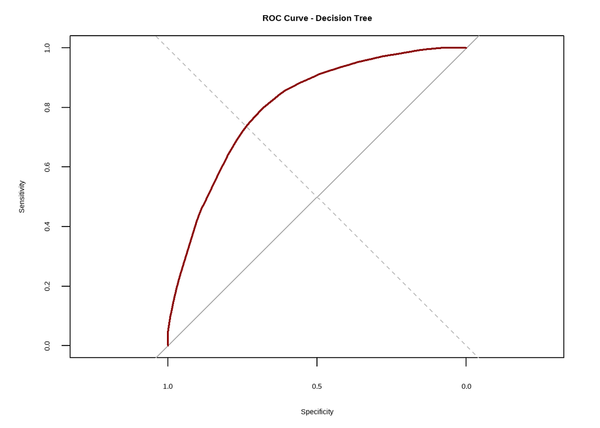

```r
# 7. ROC Curve e AUC
roc_obj <- roc(injury_df$Injury_Occurred, pred_prob)
auc_val <- auc(roc_obj)

plot(roc_obj, col = "darkred", main = "ROC Curve - Decision Tree")
abline(a = 0, b = 1, lty = 2, col = "gray")
```

```r
cat("AUC: ", round(auc_val, 3), "\n")
```

```
## AUC:  0.807
```

Valutiamo infine la calibrazione del modello per controllare che funzioni bene su tutto lo spettro delle predizioni

```r
hoslem.test(as.numeric(as.character(injury_df$Injury_Occurred)), pred_prob, g = 10)
```

```
##
##  Hosmer and Lemeshow goodness of fit (GOF) test
##
## data:  as.numeric(as.character(injury_df$Injury_Occurred)), pred_prob
## X-squared = 1000, df = 8, p-value < 2.2e-16
```

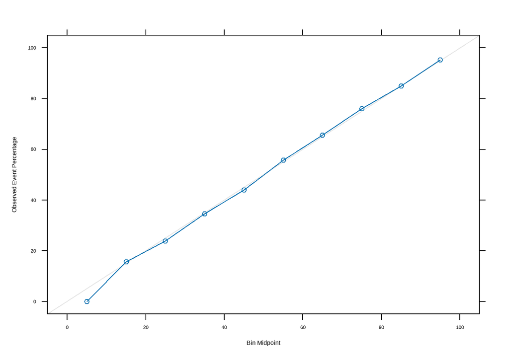

```r
df <- data.frame(obs = factor(injury_df$Injury_Occurred), pred = pred_prob)
cal <- calibration(obs ~ pred, data = df, class = "Yes", cuts = 10)
plot(cal)
```

## New Injury_Risk_Table

We now want to build a sort of look-up table for the Injury risk probability given by the tree and we thought to build a sort of heatmap on the Cumulative_fatigue_index - Impact_Force_Newton plane.

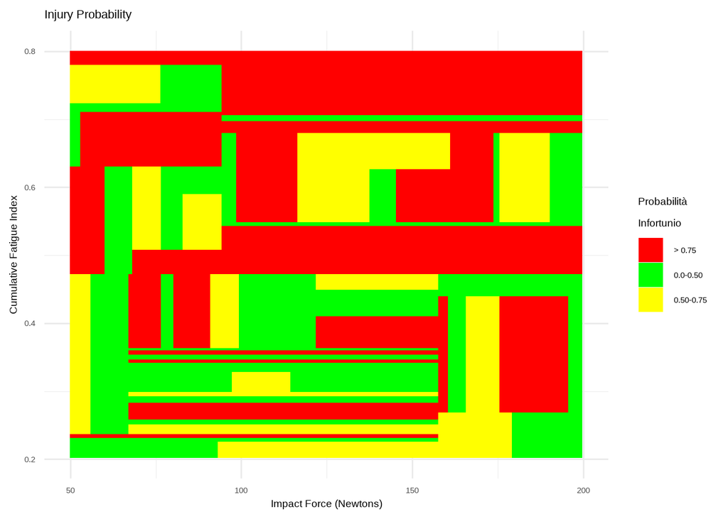

```r
x_seq <- seq(
  from = min(injury_df$Impact_Force_Newtons, na.rm = TRUE),
  to   = max(injury_df$Impact_Force_Newtons, na.rm = TRUE),
  length.out = 500    # risoluzione aumentata
)
y_seq <- seq(
  from = min(injury_df$Cumulative_Fatigue_Index, na.rm = TRUE),
  to   = max(injury_df$Cumulative_Fatigue_Index, na.rm = TRUE),
  length.out = 500
)
grid <- expand.grid(
  Impact_Force_Newtons     = x_seq,
  Cumulative_Fatigue_Index = y_seq
)
grid$pred_prob <- predict(
  tree_model,
  newdata = grid,
  type   = "prob"
)[, "Yes"]

grid$fill <- with(grid,
  ifelse(is.na(pred_prob), "green",
    ifelse(pred_prob > 0.75, "red",
      ifelse(pred_prob > 0.5, "yellow", "green")
    )
  )
)

grid <- grid %>%
  mutate(prob_range = case_when(
    fill == "green"  ~ "0.0-0.50",
    fill == "yellow" ~ "0.50-0.75",
    fill == "red"    ~ "> 0.75",
    TRUE             ~ NA_character_
  )) %>%
  mutate(prob_range = factor(prob_range,
    levels = c("> 0.75","0.0-0.50", "0.50-0.75")
  ))


ggplot(grid, aes(x = Impact_Force_Newtons, y = Cumulative_Fatigue_Index)) +
  geom_tile(aes(fill = prob_range), na.rm = TRUE) +
  scale_fill_manual(
    name = "Probabilità\nInfortunio",
    values = c(
      "0.0-0.50" = "green",
      "0.50-0.75" = "yellow",
      "> 0.75" = "red"
    )
  ) +
  labs(
    x = "Impact Force (Newtons)",
    y = "Cumulative Fatigue Index",
    title = "Injury Probability"
  ) +
  theme_minimal(base_size = 14)
```